# Econometria Aplicada a Finanças Aula 14

Mestrado Profissional em Administração

Prof. Dr. Washington S. da Silva

IFMG — Campus Formiga

17 de novembro de 2026

## Programação da aula

### Na Aula 13 estudamos:

- Variáveis instrumentais

### Hoje

- Diferença-em-diferenças com dados de corte transversal repetidos

Diferença-em-diferenças

## O problema: a política funcionou?

### Um estado elevou o salário mínimo. O emprego caiu?

Em 1º de abril de 1992, New Jersey elevou seu salário mínimo de US$ 4,25 para US$ 5,05. O estado vizinho, Pennsylvania, manteve o salário mínimo em US$ 4,25.

**Previsão da teoria padrão:** se o salário mínimo superar o salário de equilíbrio, a quantidade de trabalho demandada tende a diminuir, enquanto a quantidade ofertada tende a aumentar, *ceteris paribus*.

Trabalhadores de baixa remuneração podem ganhar mais por hora, mas alguns podem perder o emprego ou trabalhar menos horas.

**A pergunta:** como medir o efeito causal dessa política?

Não podemos observar *o que teria ocorrido* em NJ sem o aumento. Esse cenário não observado é o **contrafactual**.

$\implies$ Precisamos de uma estratégia que isole o efeito da política de tudo o mais que muda ao mesmo tempo.

## O problema: a política funcionou?

### O estudo clássico de Card e Krueger (1994)

Card e Krueger (1994) investigaram o efeito do aumento do salário mínimo sobre o emprego em restaurantes de *fast-food*.

- **Antes:** entrevistaram 410 restaurantes em NJ e PA (fevereiro–março de 1992).
- **Depois:** reentrevistaram 399 desses estabelecimentos (novembro–dezembro de 1992).
- **Desenho original:** dados em painel com dois períodos (antes e depois da intervenção), acompanhando os restaurantes de NJ e PA ao longo de 1992.

**Nesta aula:**

- Utilizaremos o problema econômico como motivação para compreender diferenças-em-diferenças.
- Para fins didáticos, suporemos dispor apenas de cortes transversais repetidos: amostras de restaurantes observadas antes e depois, sem acompanhar individualmente os mesmos estabelecimentos.

## Estruturas de dados em DiD

### Cortes transversais repetidos

Em cada período, selecionamos uma nova amostra de restaurantes dos grupos de tratamento (NJ) e controle (PA).

| Grupo | Antes (fevereiro) | Depois (novembro) |
| --- | --- | --- |
| **NJ — Tratamento** | NJ-A, NJ-B | NJ-C, NJ-D |
| **PA — Controle** | PA-A, PA-B | PA-C, PA-D |

*Identificadores ilustrativos de restaurantes.*

- **Dados em painel:** acompanhamos as mesmas unidades nos diferentes períodos.
- **Cortes transversais repetidos:** obtemos novas amostras em cada período, sem acompanhar necessariamente as mesmas unidades.

$\implies$ O estimador DiD compara as **médias dos grupos** antes e depois da intervenção, sem exigir que os mesmos restaurantes sejam observados nos dois períodos.

## O problema: a política funcionou?

### Por que não comparar o emprego em NJ antes e depois?

Suponha que o emprego no setor de fast-food de NJ fosse de 20,4 antes e de 21,0 depois do aumento.

Podemos concluir que o salário mínimo *aumentou* o emprego em 0,6 trabalhador?

**Não.** Outras coisas mudaram entre fevereiro e novembro de 1992:

- A economia nacional estava se recuperando de uma recessão.
- Padrões sazonais de contratação no setor de fast-food.
- Mudanças na demanda dos consumidores.

Uma comparação simples entre antes e depois confunde o **efeito da política** com as **tendências temporais**.

$\implies$ Precisamos de um **grupo de controle** que tenha vivenciado as mesmas tendências temporais, mas não a mudança na política.

## Efeitos de tratamento: a estrutura básica

### Grupos de tratamento e de controle

**Grupo de tratamento:** unidades que recebem a intervenção (restaurantes de NJ).

**Grupo de controle:** unidades que não a recebem (restaurantes de PA).

Defina um indicador de tratamento:

$$d_i=\begin{cases}
1 & \text{se a unidade }i\text{ recebe o tratamento},\\
0 & \text{se a unidade }i\text{ pertence ao grupo de controle}.
\end{cases}$$

Podemos comparar as médias dos dois grupos por meio de uma regressão:

$$y_i=\beta_1+\beta_2d_i+e_i$$

Trata-se apenas de uma regressão com uma variável dummy. Você já sabe estimá-la.

$\implies$ O coeficiente $\beta_2$ representa a **diferença média** em $y$ entre os grupos de tratamento e de controle.

## Efeitos de tratamento: a estrutura básica

### O estimador de diferenças

No modelo $y_i=\beta_1+\beta_2d_i+e_i$, as médias condicionais são:

- **Controle** ($d_i=0$): $E(y_i\mid d_i=0)=\beta_1$.
- **Tratamento** ($d_i=1$): $E(y_i\mid d_i=1)=\beta_1+\beta_2$.

Logo, $\beta_2$ representa a diferença entre as médias populacionais dos dois grupos.

O estimador de $\beta_2$ por MQO é simplesmente:

$$b_2=\bar y_1-\bar y_0$$

O **estimador de diferenças**: média do grupo de tratamento menos média do grupo de controle.

$\implies$ Se $b_2>0$, a média do grupo tratado é maior; se $b_2<0$, é menor.

Para interpretar essa diferença como um **efeito causal**, precisamos considerar a **comparabilidade entre os grupos**.

## Efeitos de tratamento: a estrutura básica

### Viés de seleção

Se as unidades *escolhem* receber ou não o tratamento, os grupos podem diferir em outros aspectos além do tratamento.

**Exemplo: hospitais e resultados de saúde.**

- Suponha que as pessoas que vão ao hospital tenham um escore médio de saúde de 3,21.
- As pessoas que não vão têm um escore médio de 3,93.

Diferença: $3{,}21-3{,}93=-0{,}72$. O hospital *faz você ficar mais doente*?

Claro que não. Pessoas doentes têm maior probabilidade de ir ao hospital.

$$\underbrace{\bar e_1}_{\substack{\text{erro médio de quem}\\\text{vai ao hospital}}}
\neq
\underbrace{\bar e_0}_{\substack{\text{erro médio de quem}\\\text{não vai ao hospital}}}$$

Aqui, $\bar e_1$ é o fator médio não observado de saúde de quem vai ao hospital, e $\bar e_0$, o de quem não vai. Quando $E(\bar e_1-\bar e_0)\neq0$, o estimador simples de diferenças é viesado. Esse é o **viés de seleção**.

$\implies$ A atribuição aleatória elimina o viés de seleção ao assegurar que $E(\bar e_1)=E(\bar e_0)$.

## Efeitos de tratamento: a estrutura básica

### Experimentos naturais

Experimentos com atribuição aleatória nem sempre são viáveis em Economia.

Um **experimento natural** ocorre quando uma mudança institucional ou de política gera grupos de tratamento e controle plausivelmente comparáveis, sem que o pesquisador determine a atribuição ao tratamento.

Os **cortes transversais repetidos** são especialmente úteis na **avaliação de políticas públicas e programas**, como intervenções em educação, saúde e treinamento profissional.

Permitem comparar os resultados de diferentes grupos antes e depois de uma intervenção, sem exigir que as mesmas unidades sejam observadas.

**Card e Krueger (1994):** NJ foi afetado pelo aumento do salário mínimo, enquanto PA serviu como grupo de controle.

$\implies$ Precisamos distinguir os efeitos da política das demais mudanças ocorridas ao longo do tempo.

## Diferenças em diferenças

### A ideia de DiD

Observamos ambos os grupos em **dois períodos**: antes e depois da política.

|  | Antes | Depois |
| --- | --- | --- |
| Controle (PA) | $\bar y_{C,\mathrm{Antes}}$ | $\bar y_{C,\mathrm{Depois}}$ |
| Tratamento (NJ) | $\bar y_{T,\mathrm{Antes}}$ | $\bar y_{T,\mathrm{Depois}}$ |

**Primeira diferença** (dentro de cada grupo, ao longo do tempo):

- **Controle:** $\bar y_{C,\mathrm{Depois}}-\bar y_{C,\mathrm{Antes}}$.
- **Tratamento:** $\bar y_{T,\mathrm{Depois}}-\bar y_{T,\mathrm{Antes}}$.

**Segunda diferença** (diferença das diferenças):

$$\hat\delta=
\underbrace{(\bar y_{T,\mathrm{Depois}}-\bar y_{T,\mathrm{Antes}})}_{\text{variação no tratamento}}
-\underbrace{(\bar y_{C,\mathrm{Depois}}-\bar y_{C,\mathrm{Antes}})}_{\text{variação no controle}}$$

$\implies$ Sob a **hipótese de tendências paralelas**, a variação do controle representa o que teria ocorrido com o grupo tratado sem a política.

Assim, a dupla diferença estima o **efeito do tratamento**.

## Diferenças em diferenças

### Card e Krueger (1994): a tabela $2\times2$

Dados: 410 restaurantes de fast-food (NJ e leste de PA), pesquisados em fevereiro e novembro de 1992. Resultado: FTE = empregados equivalentes em tempo integral por restaurante.

|  | Fev. 1992 | Nov. 1992 | Variação |
| --- | --- | --- | --- |
| PA (Controle) | 23,33 | 21,17 | $-2{,}17$ |
| NJ (Tratamento) | 20,44 | 21,03 | $+0{,}59$ |
| **Diferença** | $-2{,}89$ | $-0{,}14$ |  |

**Estimativa DiD:**

$$\hat\delta=(+0{,}59)-(-2{,}17)=2{,}75$$

Ou, de forma equivalente: $\hat\delta=(-0{,}14)-(-2{,}89)=2{,}75$.

O emprego em NJ *aumentou* cerca de 2,75 FTE em relação a PA.

## Diferenças em diferenças

### Visualizando DiD

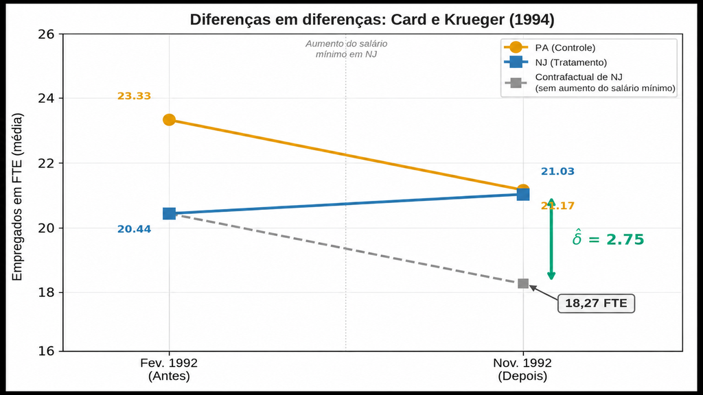

Evolução do emprego em PA e NJ. A linha tracejada representa o contrafactual de NJ (18,27 FTE), e a seta indica a estimativa DiD (2,75 FTE).

## Diferenças em diferenças

### Construção do contrafactual

Sob a hipótese de tendências paralelas, o resultado **contrafactual** é obtido somando à média inicial de NJ a variação observada em PA:

$$\begin{aligned}
\widehat{\bar Y}_{NJ,\text{pós}}^{(0)}
&=\bar Y_{NJ,\text{pré}}+
(\bar Y_{PA,\text{pós}}-\bar Y_{PA,\text{pré}})\\[4pt]
&=20{,}4394+(21{,}1656-23{,}3312)\\[4pt]
&\approx {\color{#E83E8C}18{,}27\text{ FTE}}
\end{aligned}$$

Comparando com o emprego observado em NJ após a intervenção:

$$\hat\delta=21{,}0274-18{,}2738
\approx {\color{#E83E8C}2{,}75\text{ FTE}}$$

Na **Atividade 13**, utilizaremos o mesmo procedimento para estimar a proporção contrafactual de pessoas sem seguro-saúde nos estados que expandiram o Medicaid.

## DiD como uma regressão

### Da tabela $2\times2$ a uma regressão

A estimativa DiD também pode ser obtida por meio de uma regressão linear estimada por MQO:

$$y_{it}=\beta_1+\beta_2\mathrm{NJ}_i+\beta_3\mathrm{Depois}_t
+\delta\,(\mathrm{NJ}_i\times\mathrm{Depois}_t)+e_{it}$$

O modelo utiliza variáveis que você já conhece:

- $\mathrm{NJ}_i$: vale **1** para restaurantes de NJ e **0** para restaurantes de PA.
- $\mathrm{Depois}_t$: vale **1** em novembro de 1992 e **0** em fevereiro de 1992.
- $\mathrm{NJ}_i\times\mathrm{Depois}_t$: termo de interação que vale **1 apenas para restaurantes de NJ após a intervenção**.

$\implies$ O coeficiente da interação, $\delta$, representa a **dupla diferença** entre as médias dos grupos nos dois períodos.

## DiD como uma regressão

### O significado de cada coeficiente

$$y_{it}=\beta_1+\beta_2\mathrm{NJ}_i+\beta_3\mathrm{Depois}_t
+\delta\,(\mathrm{NJ}_i\times\mathrm{Depois}_t)+e_{it}$$

Escreva a função de regressão para cada célula:

|  | Antes ($\mathrm{Depois}=0$) | Depois ($\mathrm{Depois}=1$) |
| --- | --- | --- |
| PA ($\mathrm{NJ}=0$) | $\beta_1$ | $\beta_1+\beta_3$ |
| NJ ($\mathrm{NJ}=1$) | $\beta_1+\beta_2$ | $\beta_1+\beta_2+\beta_3+\delta$ |

- $\beta_1=23{,}33$: média de PA antes da política (célula de referência).
- $\beta_2=-2{,}89$: NJ estava 2,89 FTE *abaixo* de PA antes da política.
- $\beta_3=-2{,}17$: o emprego em PA caiu 2,17 (tendência temporal).
- $\delta=2{,}75$: entre fevereiro e novembro de 1992, a variação do emprego médio em NJ superou em **2,75 FTE** a variação observada em PA. Sob a hipótese de tendências paralelas, essa diferença estima o efeito do aumento do salário mínimo sobre o emprego em NJ.

## DiD como uma regressão

### Verificação: $\delta$ recupera a fórmula DiD

A partir da tabela das funções de regressão:

**Variação em NJ:**

$$(\beta_1+\beta_2+\beta_3+\delta)-(\beta_1+\beta_2)=\beta_3+\delta$$

**Variação em PA:**

$$(\beta_1+\beta_3)-\beta_1=\beta_3$$

**Diferença das diferenças:**

$$(\beta_3+\delta)-\beta_3=\delta$$

$\implies$ O coeficiente $\delta$ do termo de interação é exatamente o estimador DiD.

Podemos testar $H_0:\delta=0$ com um teste $t$ usual. Nos dados de Card e Krueger: $t\approx1{,}63$, $p\approx0{,}10$ (bilateral). Não rejeitamos ao nível de 5%. Um teste bilateral é apropriado porque o salário mínimo poderia, plausivelmente, aumentar ou reduzir o emprego.

## DiD como uma regressão

### Adicionando controles

Como em qualquer regressão, podemos adicionar variáveis de controle:

$$\begin{aligned}
y_{it}={}&\beta_1+\beta_2\mathrm{NJ}_i+\beta_3\mathrm{Depois}_t
+\delta\,(\mathrm{NJ}_i\times\mathrm{Depois}_t)\\
&+\gamma_1\mathrm{KFC}_i+\gamma_2\mathrm{Roys}_i+\gamma_3\mathrm{Wendys}_i+e_{it}
\end{aligned}$$

Card e Krueger adicionaram:

- Dummies de redes (KFC, Roy Rogers, Wendy’s; Burger King = referência).
- Indicadores regionais dentro de NJ.

Resultado: $\hat\delta$ praticamente não muda. A estimativa do efeito do tratamento é robusta à inclusão desses controles.

$\implies$ Adicionar controles pode melhorar a precisão e testar a robustez, assim como na regressão múltipla (Tópico 13).

## A hipótese de tendências paralelas

### O que torna DiD válido?

DiD supõe que, na ausência do tratamento, ambos os grupos teriam apresentado a **mesma variação ao longo do tempo**.

Essa é a **hipótese de tendências paralelas** (também chamada de **tendências comuns**).

Formalmente:

$$E(y_{T,\mathrm{Depois}}^{(0)})-E(y_{T,\mathrm{Antes}})
=E(y_{C,\mathrm{Depois}})-E(y_{C,\mathrm{Antes}})$$

em que $y_{T,\mathrm{Depois}}^{(0)}$ é o **resultado contrafactual** do grupo de tratamento.

Em palavras: a tendência do grupo de tratamento (na ausência do tratamento) teria acompanhado a tendência do grupo de controle.

Os **níveis** podem diferir. As **tendências** devem ser iguais.

## A hipótese de tendências paralelas

### Quando as tendências paralelas são satisfeitas

[figure not shown]

Antes do tratamento, ambos os grupos seguem a mesma tendência (as linhas são paralelas). Após o tratamento, o grupo de tratamento diverge. DiD capta corretamente $\hat\delta$.

## A hipótese de tendências paralelas

### Quando as tendências paralelas são violadas

[figure not shown]

O grupo de tratamento já crescia mais rapidamente antes da política. DiD usa a tendência do grupo de controle como contrafactual (tracejado vermelho), que fica abaixo do contrafactual correto.

## A hipótese de tendências paralelas

### Podemos testar as tendências paralelas?

**Rigorosamente, não.** A hipótese diz respeito ao *contrafactual* (o que teria ocorrido), que nunca observamos.

**Mas podemos avaliar sua plausibilidade:**

1. Represente graficamente as tendências de ambos os grupos antes do tratamento. Se elas se acompanhavam antes, é mais plausível que tivessem continuado assim.
2. Faça um “teste placebo”: aplique DiD a um período *anterior* ao tratamento efetivo. Se encontrar um “efeito”, a hipótese de tendências paralelas se torna questionável.
3. Adicione controles para diferenças observáveis que possam causar tendências divergentes.

$\implies$ A hipótese de tendências paralelas é fundamentalmente **não testável**, mas evidências fortes no período anterior ao tratamento a tornam mais convincente.

No caso de Card e Krueger: NJ e PA são estados vizinhos, com mercados de fast-food semelhantes. A hipótese é plausível, embora seja objeto de debate.

## DiD e as ferramentas de regressão

### Estimação e interpretação causal

| Ferramenta | Papel em DiD |
| --- | --- |
| Variáveis indicadoras | Identificam os grupos ($\mathrm{NJ}_i$) e os períodos ($\mathrm{Depois}_t$). |
| Termo de interação | $\mathrm{NJ}_i\times\mathrm{Depois}_t$: seu coeficiente $\delta$ representa a dupla diferença. |
| Mínimos quadrados ordinários | Estimação de $\delta$ por regressão linear. |
| Inferência estatística | Avaliação da incerteza de $\hat\delta$ e teste de $H_0:\delta=0$. |
| Variáveis de controle | Podem ajustar diferenças observáveis entre grupos e períodos. |

$\implies$ A regressão permite estimar DiD, mas sua **interpretação causal** depende de hipóteses de identificação, especialmente das **tendências paralelas**.

## Efeitos de tratamento

### Síntese: diferenças entre grupos e viés de seleção

1. Um **efeito de tratamento** é o impacto causal de uma política ou intervenção sobre uma variável de resultado.
2. O **estimador de diferenças** compara as médias dos grupos:

   $$b_2=\bar y_1-\bar y_0$$

   Sob **atribuição aleatória**, essa diferença estima o efeito médio do tratamento.
3. O **viés de seleção** surge quando os grupos de tratamento e controle diferem sistematicamente em características que também afetam o resultado.
4. **Experimentos naturais** podem oferecer grupos de tratamento e controle plausíveis para investigar efeitos causais.

## Diferenças-em-diferenças

### Síntese: estimação e interpretação causal

1. **Diferenças-em-diferenças (DiD)** utiliza dois grupos (tratamento e controle) e dois períodos (antes e depois).
2. O estimador DiD compara as **variações das médias** dos grupos:

   $$\hat\delta =
   (\bar y_{T,1}-\bar y_{T,0})
   -(\bar y_{C,1}-\bar y_{C,0})$$
3. Na **regressão linear**, o coeficiente da interação entre tratamento e período posterior corresponde à dupla diferença.
4. Sob a **hipótese de tendências paralelas**, DiD permite estimar o efeito causal da intervenção sobre o grupo tratado.
5. DiD pode utilizar **dados em painel** ou **cortes transversais repetidos**. Nesta aula, adotamos a segunda estrutura.

## Aplicações de DiD com cortes transversais repetidos

- **Brasil — Bolsa Família:** Chitolina, Foguel e Menezes-Filho (2016)

  PNAD (2006 e 2009). Efeito da expansão do benefício para jovens de 16–17 anos sobre a frequência escolar. [Acessar artigo](https://doi.org/10.5935/0034-7140.20160009).
- **Brasil — Leis de meia-entrada:** Wink Junior *et al.* (2016)

  POF (1987/88, 1995/96, 2002/03 e 2008/09). Efeitos das leis sobre o consumo e os gastos culturais dos estudantes. [Acessar artigo](https://doi.org/10.1590/0101-416146471mfsp).
- **Estados Unidos — Cobertura de maternidade:** Gruber (1994)

  CPS (1974–75 e 1977–78). Efeitos da obrigatoriedade de cobertura de maternidade nos seguros-saúde sobre salários e emprego. [Acessar artigo](https://pricetheory.uchicago.edu/levitt/Papers/Gruber1994.pdf).

## Síntese da disciplina

### O que estudamos?

- **Regressão linear:** especificação, MQO, interpretação, exogeneidade, endogeneidade, vieses e consistência.
- **Inferência e diagnóstico:** heterocedasticidade, erros-padrão robustos, dependência entre observações, autocorrelação, quebras estruturais e observações influentes.
- **Outros modelos:** regressões robusta e quantílica; modelos para resultados binários, multinomiais e ordinais.
- **Inferência causal:** experimentos aleatorizados, variáveis instrumentais (VI/MQ2E) e diferenças-em-diferenças.

**Fio condutor:** formular perguntas empíricas, explicitar hipóteses, estimar modelos, avaliar a incerteza e comunicar resultados de forma reprodutível.

## Inferência causal: princípios e limites

- **Associação não implica causalidade.** Um coeficiente estimado não representa necessariamente um efeito causal.
- **A identificação é fundamental:** experimentos aleatorizados, VI e DiD dependem de hipóteses específicas para sustentar interpretações causais.
- **Inferência robusta não corrige endogeneidade.** Erros-padrão, intervalos de confiança e valores-p quantificam a incerteza, mas não garantem identificação causal.

**Além do escopo da disciplina:** regressão descontínua, pareamento por escore de propensão, controle sintético e extensões de DiD com múltiplos períodos e efeitos heterogêneos.

$\implies$ Uma **análise empírica crível** exige hipóteses justificadas, métodos adequados, interpretação cuidadosa e reprodutibilidade.

Atividade 13

[Veja na página cronograma do site da disciplina](https://washingtonsilva.github.io/site_mpa_ecnt01_2026/cronograma.html#aula-13-101126)

## Referências

CARD, D.; KRUEGER, A. B. [Minimum Wages and Employment: A Case Study of the Fast-Food Industry in New Jersey and Pennsylvania](https://www.jstor.org/stable/2118030). **American Economic Review**, v. 84, n. 4, p. 772–793, 1994.

CHITOLINA, L.; FOGUEL, M. N.; MENEZES-FILHO, N. A. [The Impact of the Expansion of the Bolsa Família Program on the Time Allocation of Youths and Their Parents](https://doi.org/10.5935/0034-7140.20160009). **Revista Brasileira de Economia**, v. 70, n. 2, p. 183–202, 2016.

GRUBER, J. [The Incidence of Mandated Maternity Benefits](https://www.jstor.org/stable/2118071). **American Economic Review**, v. 84, n. 3, p. 622–641, 1994.

HILL, R. C.; GRIFFITHS, W. E.; LIM, G. C. **Principles of Econometrics**. 5. ed. Hoboken, NJ: Wiley, 2018.

WINK JUNIOR, M. V. *et al.* [Os efeitos da criação de leis de meia entrada para estudantes sobre o consumo de bens e serviços culturais no Brasil](https://doi.org/10.1590/0101-416146471mfsp). **Estudos Econômicos (São Paulo)**, v. 46, n. 4, p. 745–781, 2016.

WOOLDRIDGE, J. M. **Introdução à Econometria: Uma Abordagem Moderna**. São Paulo: Thomson, 2006.